# 25_Tata_Capital_ML_Assignment3

```python
# For Data Manipulation
import pandas as pd
import numpy as np

# For Data Visualization
%matplotlib inline
import matplotlib.pyplot as plt
import seaborn as sns

from sklearn.cluster import KMeans

# For supressing warning messages
import warnings
warnings.filterwarnings('ignore')
```

```python
data_df = pd.read_csv("25_Tata_Capital.csv")
```

```python
data_df.head()
```

|  | ClientID | Years_In_Business | Annual_Revenue_INR_Cr | Loan_Outstanding_INR_Cr | Debt_to_Equity_Ratio | Interest_Coverage_Ratio | Current_Ratio | DPD_Instances_Last_12M | Credit_Rating_Score | New_Loan_Requests_Last_2Y | Collateral_Coverage_Pct | Business_Sector | Company_Size | Loan_Type | Repayment_Track | Geographic_Region |
| --- | --- | --- | --- | --- | --- | --- | --- | --- | --- | --- | --- | --- | --- | --- | --- | --- |
| 0 | TAC011791 | 7.35 | 3707.81 | 196.44 | 3.24 | 9.47 | 0.85 | 0.0 | 7.25 | 3 | 110.48 | Healthcare | Small | Term Loan | Satisfactory | West |
| 1 | TAC002036 | 20.71 | 765.38 | 349.29 | 5.53 | NaN | 0.37 | 4.0 | 3.55 | 5 | 203.57 | Healthcare | Medium | Working Capital | Watchlist | North |
| 2 | TAC008728 | 1.00 | 607.78 | 82.69 | 3.75 | 5.52 | 2.03 | 7.0 | 8.60 | 0 | 111.07 | Services | Small | Working Capital | Excellent | West |
| 3 | TAC007765 | 2.52 | 751.05 | 166.79 | 7.24 | 14.68 | 1.43 | 6.0 | 6.56 | 0 | 182.13 | Real Estate | Large | Term Loan | Good | South |
| 4 | TAC003327 | 1.00 | 904.69 | 117.65 | 2.97 | 10.07 | 2.78 | 6.0 | 10.00 | 1 | 96.64 | Services | Small | Project Finance | Satisfactory | East |

## Task 1 — Data Quality Check

- Print the shape of the dataset (rows × columns).
- Display data types for all columns.
- Identify columns with missing values — report count and percentage per column.
- Check for and report any duplicate rows.
- Detect outlier-prone numerical columns using the IQR method and list them.
- Write a 3-sentence markdown summary of overall data quality findings.

```python
data_df.shape
```

```
(19000, 16)
```

There are 19000 Rows & 16 Columns in this dataset.

```python
data_df.info()
```

```
<class 'pandas.core.frame.DataFrame'>
RangeIndex: 19000 entries, 0 to 18999
Data columns (total 16 columns):
 #   Column                     Non-Null Count  Dtype
---  ------                     --------------  -----
 0   ClientID                   19000 non-null  object
 1   Years_In_Business          19000 non-null  float64
 2   Annual_Revenue_INR_Cr      19000 non-null  float64
 3   Loan_Outstanding_INR_Cr    19000 non-null  float64
 4   Debt_to_Equity_Ratio       18203 non-null  float64
 5   Interest_Coverage_Ratio    18243 non-null  float64
 6   Current_Ratio              19000 non-null  float64
 7   DPD_Instances_Last_12M     18148 non-null  float64
 8   Credit_Rating_Score        19000 non-null  float64
 9   New_Loan_Requests_Last_2Y  19000 non-null  int64
 10  Collateral_Coverage_Pct    19000 non-null  float64
 11  Business_Sector            19000 non-null  object
 12  Company_Size               19000 non-null  object
 13  Loan_Type                  19000 non-null  object
 14  Repayment_Track            18250 non-null  object
 15  Geographic_Region          19000 non-null  object
dtypes: float64(9), int64(1), object(6)
memory usage: 2.3+ MB
```

There are 16 Columns in this dataset out of which 10 are numeric in nature (9 float & 1 integer) and 6 categories.

```python
s1 = data_df.isnull().sum()   # Creates a series of count of missing values for each column
s2 = data_df.isnull().sum() / data_df.shape[0] * 100 # Creates a series of percentage of missing values for each column


# Display both the output together

missing = pd.concat([s1, s2], axis=1)
missing.columns = ["Count of Missing Values", "Percentage of Missing Values"]

print('Total Count of Missing Values in the data is:', data_df.isnull().sum().sum())

missing
```

```
Total Count of Missing Values in the data is: 3156
```

|  | Count of Missing Values | Percentage of Missing Values |
| --- | --- | --- |
| ClientID | 0 | 0.000000 |
| Years_In_Business | 0 | 0.000000 |
| Annual_Revenue_INR_Cr | 0 | 0.000000 |
| Loan_Outstanding_INR_Cr | 0 | 0.000000 |
| Debt_to_Equity_Ratio | 797 | 4.194737 |
| Interest_Coverage_Ratio | 757 | 3.984211 |
| Current_Ratio | 0 | 0.000000 |
| DPD_Instances_Last_12M | 852 | 4.484211 |
| Credit_Rating_Score | 0 | 0.000000 |
| New_Loan_Requests_Last_2Y | 0 | 0.000000 |
| Collateral_Coverage_Pct | 0 | 0.000000 |
| Business_Sector | 0 | 0.000000 |
| Company_Size | 0 | 0.000000 |
| Loan_Type | 0 | 0.000000 |
| Repayment_Track | 750 | 3.947368 |
| Geographic_Region | 0 | 0.000000 |

DPD_Instances_Last_12M has the highest percentage of missing value with 4.48% of the data missing.

```python
data_df.duplicated().sum()
```

```
np.int64(0)
```

There are no duplicates in this dataset.

```python
data_df.duplicated().sum() / data_df.shape[0] * 100
```

```
np.float64(0.0)
```

There are no duplicates in this dataset, hence 0.0% of the data is duplicate.

```python
num_cols = data_df.select_dtypes(include='number').columns.to_list()
num_cols
```

```
['Years_In_Business',
 'Annual_Revenue_INR_Cr',
 'Loan_Outstanding_INR_Cr',
 'Debt_to_Equity_Ratio',
 'Interest_Coverage_Ratio',
 'Current_Ratio',
 'DPD_Instances_Last_12M',
 'Credit_Rating_Score',
 'New_Loan_Requests_Last_2Y',
 'Collateral_Coverage_Pct']
```

```python
cat_cols = [col for col in data_df.columns if col not in num_cols]
cat_cols
```

```
['ClientID',
 'Business_Sector',
 'Company_Size',
 'Loan_Type',
 'Repayment_Track',
 'Geographic_Region']
```

```python
outlier_columns = []

for col in num_cols:

    Q1 = data_df[col].quantile(0.25)
    Q3 = data_df[col].quantile(0.75)

    IQR = Q3 - Q1

    lower = Q1 - 1.5 * IQR
    upper = Q3 + 1.5 * IQR

    outliers = data_df[(data_df[col] < lower) | (data_df[col] > upper)]

    if len(outliers) > 0:
        outlier_columns.append(col)

outlier_columns
```

```
['Debt_to_Equity_Ratio', 'Current_Ratio']
```

The `Debt_to_Equity_Ratio` and `Current_Ratio`columns contain outliers.

#### Data Quality Findings Summary

- The dataset contains 19000 rows and 16 columns with no duplicates. The dataset contains 16 columns. There are 6 categorical columns and 10 numerical columns.
- Four columns have missing data: Debt_to_Equity_Ratio (4.19%), Interest_Coverage_Ratio (3.98%), DPD_Instances_Last_12M (4.48%) and Repayment_Track (3.94%).
- The Debt_to_Equity_Ratio and Current_Ratio columns contain outliers.

## Task 2 — Data Exploration

- Display summary statistics for all numerical features.
- For every categorical column show value counts and the percentage share of each category.
- Identify the top-3 categories in the most important categorical column by mean of the primary numerical metric.
- Comment on notable skews, imbalances, or distribution patterns in a markdown cell.

```python
data_df.describe().T
```

|  | count | mean | std | min | 25% | 50% | 75% | max |
| --- | --- | --- | --- | --- | --- | --- | --- | --- |
| Years_In_Business | 19000.0 | 15.363776 | 11.180198 | 1.0 | 5.1700 | 14.55 | 23.7800 | 40.00 |
| Annual_Revenue_INR_Cr | 19000.0 | 1514.577635 | 1257.741460 | 1.0 | 478.6600 | 742.47 | 3037.0075 | 4142.26 |
| Loan_Outstanding_INR_Cr | 19000.0 | 159.305049 | 95.931204 | 0.1 | 89.7775 | 141.00 | 243.0900 | 411.79 |
| Debt_to_Equity_Ratio | 18203.0 | 5.412001 | 1.765596 | 0.0 | 4.1900 | 5.38 | 6.6000 | 10.00 |
| Interest_Coverage_Ratio | 18243.0 | 8.984450 | 4.165317 | 0.5 | 6.0300 | 8.96 | 11.9600 | 20.00 |
| Current_Ratio | 19000.0 | 1.609191 | 0.816489 | 0.3 | 0.9900 | 1.59 | 2.1800 | 4.89 |
| DPD_Instances_Last_12M | 18148.0 | 5.277937 | 3.891076 | 0.0 | 2.0000 | 5.00 | 9.0000 | 12.00 |
| Credit_Rating_Score | 19000.0 | 7.170963 | 2.294780 | 1.0 | 5.5900 | 7.45 | 9.2000 | 10.00 |
| New_Loan_Requests_Last_2Y | 19000.0 | 2.679526 | 1.970887 | 0.0 | 1.0000 | 3.00 | 4.0000 | 8.00 |
| Collateral_Coverage_Pct | 19000.0 | 148.285520 | 65.869604 | 50.0 | 95.4450 | 145.40 | 194.9300 | 300.00 |

Above is the 5-point summary for all numeric columns.

```python
data_df.describe(include='object')
```

|  | ClientID | Business_Sector | Company_Size | Loan_Type | Repayment_Track | Geographic_Region |
| --- | --- | --- | --- | --- | --- | --- |
| count | 19000 | 19000 | 19000 | 19000 | 18250 | 19000 |
| unique | 19000 | 8 | 4 | 5 | 5 | 5 |
| top | TAC007958 | Manufacturing | Small | Working Capital | Good | West |
| freq | 1 | 3870 | 6008 | 5804 | 5938 | 4796 |

Above is the descriptive summary for all categorical columns.

```python
from IPython.display import display

for col in cat_cols:

    print("\nColumn:", col)

    counts = data_df[col].value_counts()
    percent = data_df[col].value_counts(normalize=True) * 100

    table = pd.concat([counts, percent], axis=1)
    table.columns = ["Count", "Percentage"]

    display(table)
```

```
Column: ClientID
```

| ClientID | Count | Percentage |
| --- | --- | --- |
| TAC007958 | 1 | 0.005263 |
| TAC011791 | 1 | 0.005263 |
| TAC002036 | 1 | 0.005263 |
| TAC008728 | 1 | 0.005263 |
| TAC007765 | 1 | 0.005263 |
| ... | ... | ... |
| TAC001524 | 1 | 0.005263 |
| TAC007593 | 1 | 0.005263 |
| TAC014385 | 1 | 0.005263 |
| TAC006000 | 1 | 0.005263 |
| TAC014638 | 1 | 0.005263 |

19000 rows × 2 columns

```
Column: Business_Sector
```

| Business_Sector | Count | Percentage |
| --- | --- | --- |
| Manufacturing | 3870 | 20.368421 |
| Services | 3457 | 18.194737 |
| Retail | 2844 | 14.968421 |
| Real Estate | 2245 | 11.815789 |
| Healthcare | 2191 | 11.531579 |
| IT | 1898 | 9.989474 |
| Infrastructure | 1577 | 8.300000 |
| FMCG | 918 | 4.831579 |

```
Column: Company_Size
```

| Company_Size | Count | Percentage |
| --- | --- | --- |
| Small | 6008 | 31.621053 |
| Medium | 5395 | 28.394737 |
| Micro | 4144 | 21.810526 |
| Large | 3453 | 18.173684 |

```
Column: Loan_Type
```

| Loan_Type | Count | Percentage |
| --- | --- | --- |
| Working Capital | 5804 | 30.547368 |
| Term Loan | 5296 | 27.873684 |
| Project Finance | 2982 | 15.694737 |
| Equipment Finance | 2632 | 13.852632 |
| CC/OD | 2286 | 12.031579 |

```
Column: Repayment_Track
```

| Repayment_Track | Count | Percentage |
| --- | --- | --- |
| Good | 5938 | 32.536986 |
| Excellent | 5089 | 27.884932 |
| Satisfactory | 3999 | 21.912329 |
| Watchlist | 2137 | 11.709589 |
| NPA | 1087 | 5.956164 |

```
Column: Geographic_Region
```

| Geographic_Region | Count | Percentage |
| --- | --- | --- |
| West | 4796 | 25.242105 |
| North | 4103 | 21.594737 |
| South | 3839 | 20.205263 |
| East | 3437 | 18.089474 |
| Central | 2825 | 14.868421 |

- Categorical data shows that the majority of our corporate clients operate in the Manufacturing (20%) and Services (18%) sectors.
- The portfolio is heavily focused on Small (31%) and Medium (28%) enterprises with most relying on Working Capital and Term Loans.
- While the vast majority of our clients maintain a healthy repayment track, a critical 17.6% fall into high-risk categories like 'Watchlist' or 'NPA' (defaults).
- Geographically, our business is well-spread but slightly concentrated in the Western and Northern regions.

#### Calculate Skewness

##### Since Descriptive Statistics can be calculated only for continuous numeric columns, first we have to filter the data only for those columns.

##### Filter the data only for continuous numeric columns selected in the previous step.

```python
num_data = data_df[num_cols]    # Filter for these columns and save it to a new dataframe
num_data

num_data.skew()
```

```
Years_In_Business            0.368235
Annual_Revenue_INR_Cr        0.591413
Loan_Outstanding_INR_Cr      0.158964
Debt_to_Equity_Ratio         0.090471
Interest_Coverage_Ratio      0.051352
Current_Ratio                0.277656
DPD_Instances_Last_12M       0.086874
Credit_Rating_Score         -0.555436
New_Loan_Requests_Last_2Y    0.438702
Collateral_Coverage_Pct      0.285420
dtype: float64
```

##### Adding skewness, range, iqr, variance to the Summary Table.

```python
num_summary = num_data.describe().T
num_summary['skew'] = num_data.skew()
num_summary['range'] = num_data.max() - num_data.min()
num_summary['iqr'] = num_summary['75%'] - num_summary['25%']
num_summary['variance'] = num_summary['std'] ** 2
num_summary
```

|  | count | mean | std | min | 25% | 50% | 75% | max | skew | range | iqr | variance |
| --- | --- | --- | --- | --- | --- | --- | --- | --- | --- | --- | --- | --- |
| Years_In_Business | 19000.0 | 15.363776 | 11.180198 | 1.0 | 5.1700 | 14.55 | 23.7800 | 40.00 | 0.368235 | 39.00 | 18.6100 | 1.249968e+02 |
| Annual_Revenue_INR_Cr | 19000.0 | 1514.577635 | 1257.741460 | 1.0 | 478.6600 | 742.47 | 3037.0075 | 4142.26 | 0.591413 | 4141.26 | 2558.3475 | 1.581914e+06 |
| Loan_Outstanding_INR_Cr | 19000.0 | 159.305049 | 95.931204 | 0.1 | 89.7775 | 141.00 | 243.0900 | 411.79 | 0.158964 | 411.69 | 153.3125 | 9.202796e+03 |
| Debt_to_Equity_Ratio | 18203.0 | 5.412001 | 1.765596 | 0.0 | 4.1900 | 5.38 | 6.6000 | 10.00 | 0.090471 | 10.00 | 2.4100 | 3.117330e+00 |
| Interest_Coverage_Ratio | 18243.0 | 8.984450 | 4.165317 | 0.5 | 6.0300 | 8.96 | 11.9600 | 20.00 | 0.051352 | 19.50 | 5.9300 | 1.734987e+01 |
| Current_Ratio | 19000.0 | 1.609191 | 0.816489 | 0.3 | 0.9900 | 1.59 | 2.1800 | 4.89 | 0.277656 | 4.59 | 1.1900 | 6.666543e-01 |
| DPD_Instances_Last_12M | 18148.0 | 5.277937 | 3.891076 | 0.0 | 2.0000 | 5.00 | 9.0000 | 12.00 | 0.086874 | 12.00 | 7.0000 | 1.514047e+01 |
| Credit_Rating_Score | 19000.0 | 7.170963 | 2.294780 | 1.0 | 5.5900 | 7.45 | 9.2000 | 10.00 | -0.555436 | 9.00 | 3.6100 | 5.266013e+00 |
| New_Loan_Requests_Last_2Y | 19000.0 | 2.679526 | 1.970887 | 0.0 | 1.0000 | 3.00 | 4.0000 | 8.00 | 0.438702 | 8.00 | 3.0000 | 3.884396e+00 |
| Collateral_Coverage_Pct | 19000.0 | 148.285520 | 65.869604 | 50.0 | 95.4450 | 145.40 | 194.9300 | 300.00 | 0.285420 | 250.00 | 99.4850 | 4.338805e+03 |

## Task 3 — Exploratory Data Analysis (EDA)

- Plot histograms with KDE overlay for at least 3 key numerical columns. Comment on skewness.
- Create boxplots comparing a key numerical metric across levels of a categorical variable.
- Compute and visualise the correlation heatmap for all numerical features.
- Plot a grouped aggregation (e.g., bar chart of mean metric grouped by a category).
- State at least 3 specific, data-backed insights in markdown cells.

### Plot histograms with KDE overlay for at least 3 key numerical columns. Comment on skewness.

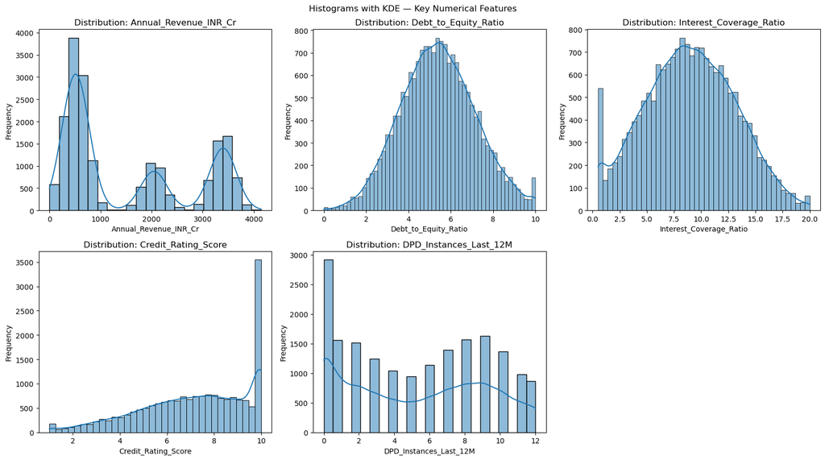

```python
key_hist = ['Annual_Revenue_INR_Cr','Debt_to_Equity_Ratio',
            'Interest_Coverage_Ratio','Credit_Rating_Score','DPD_Instances_Last_12M']

plt.figure(figsize=(15,4))

ffig, axes = plt.subplots(2, 3, figsize=(16, 9))
axes = axes.flatten()
for i, col in enumerate(key_hist):
    sns.histplot(data_df[col].dropna(), kde=True, ax=axes[i])
    axes[i].set_title(f'Distribution: {col}')
    axes[i].set_xlabel(col)
    axes[i].set_ylabel('Frequency')
axes[5].set_visible(False)

plt.suptitle('Histograms with KDE — Key Numerical Features')

plt.tight_layout()
plt.show()
```

### Create boxplots comparing a key numerical metric across levels of a categorical variable.

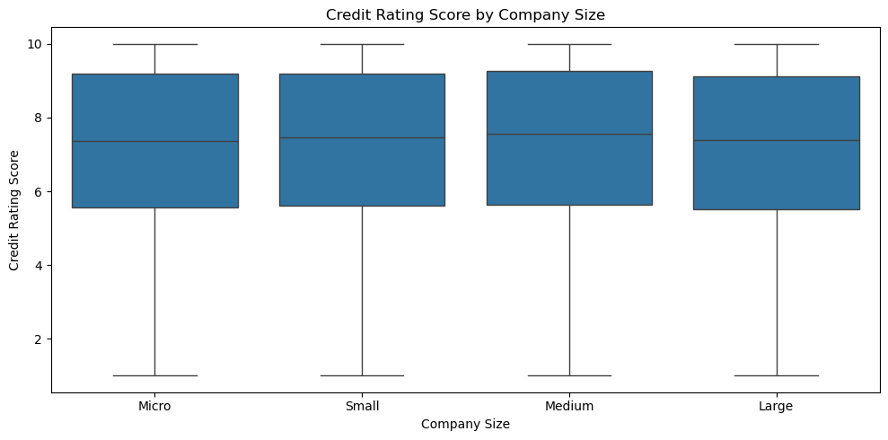

```python
# 3.2  Boxplot — Credit Rating Score by Company Size
fig, ax = plt.subplots(figsize=(10, 5))
order_sz = ['Micro', 'Small', 'Medium', 'Large']

sns.boxplot(data=data_df, x='Company_Size', y='Credit_Rating_Score', order=order_sz)
ax.set_title('Credit Rating Score by Company Size')
ax.set_xlabel('Company Size')
ax.set_ylabel('Credit Rating Score')
plt.tight_layout()
plt.show()
```

#### Compute and visualise the correlation heatmap for all numerical features.

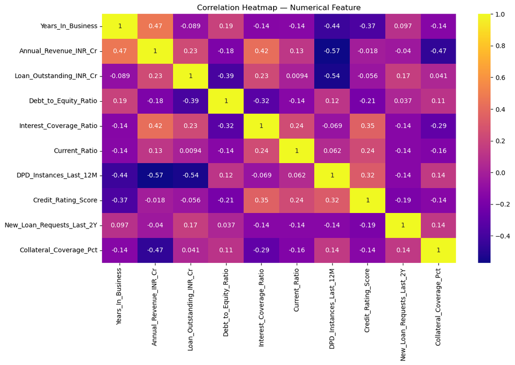

```python
# Select only numerical variables for visualizing correlation in the data

fig, ax = plt.subplots(figsize=(12, 8))
sns.heatmap(data_df.select_dtypes(include = 'number').corr(), annot = True, cmap = 'plasma')
ax.set_title('Correlation Heatmap — Numerical Feature')
plt.tight_layout()
plt.show()
```

#### Plot a grouped aggregation (e.g., bar chart of mean metric grouped by a category).

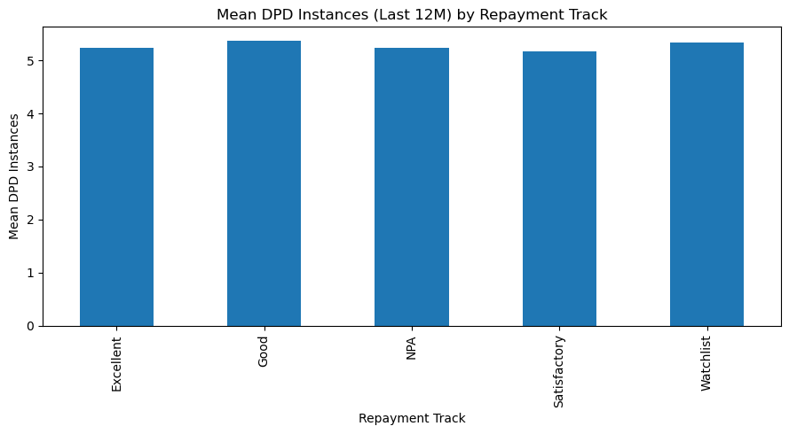

```python
# 3.4  Grouped Bar — Mean DPD by Repayment Track
fig, ax = plt.subplots(figsize=(9, 5))
dpd_means = data_df.groupby('Repayment_Track')['DPD_Instances_Last_12M'].mean()
dpd_means.plot(kind='bar')
ax.set_title('Mean DPD Instances (Last 12M) by Repayment Track')
ax.set_xlabel('Repayment Track')
ax.set_ylabel('Mean DPD Instances')
plt.tight_layout()
plt.show()
```

## Task 4 — Visualization

Produce at least 6 well-formatted charts. Each must have a descriptive title, labelled axes, and a 1–2 sentence written observation in a markdown cell directly below it.

- Chart 1: Distribution of the primary categorical feature (bar chart or pie chart)
- Chart 2: Scatter plot of two key numerical features, colour-coded by a categorical variable
- Chart 3: Boxplot of a key metric grouped by a tier, band, or classification column
- Chart 4: Grouped or stacked bar chart combining two categorical features
- Chart 5: Heatmap of average numerical features grouped by a categorical column
- Chart 6: Chart of your own choice — must reveal an insight not covered in Charts 1–5

#### Chart 1: Distribution of the primary categorical feature (bar chart or pie chart)

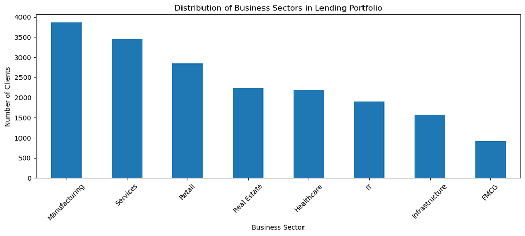

```python
# Chart 1: Distribution of Business Sector
plt.figure(figsize=(11,5))
sector_counts = data_df['Business_Sector'].value_counts()
sector_counts.plot(kind='bar')

plt.title("Distribution of Business Sectors in Lending Portfolio")
plt.xlabel("Business Sector")
plt.ylabel("Number of Clients")
plt.xticks(rotation=45)
plt.tight_layout()
plt.show()
```

#### Chart 2: Scatter plot of two key numerical features, colour-coded by a categorical variable

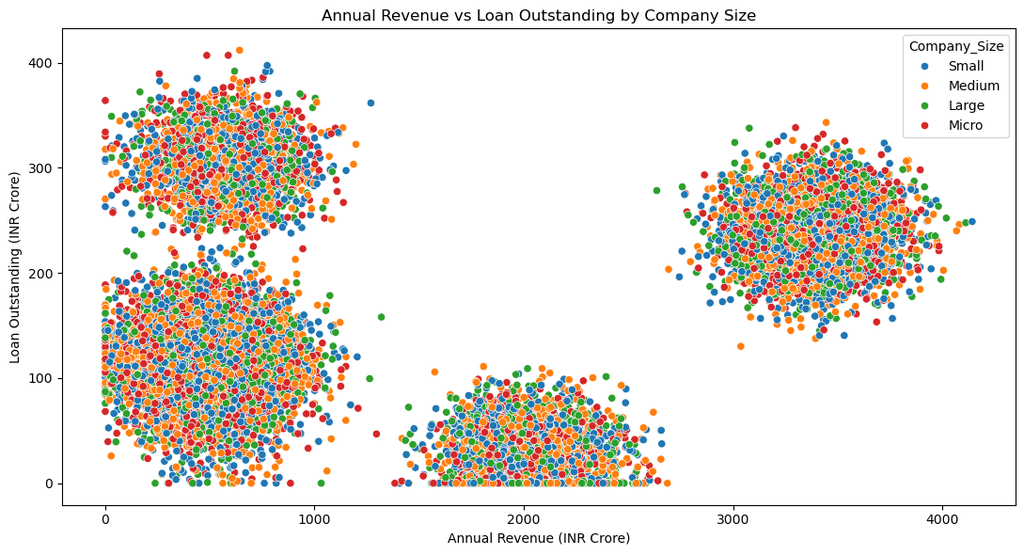

```python
# Chart 2: Scatter — Annual Revenue vs Loan Outstanding by Company Size
plt.figure(figsize=(11,6))

sns.scatterplot(data=data_df, x='Annual_Revenue_INR_Cr', y='Loan_Outstanding_INR_Cr', hue='Company_Size')

plt.title("Annual Revenue vs Loan Outstanding by Company Size")
plt.xlabel("Annual Revenue (INR Crore)")
plt.ylabel("Loan Outstanding (INR Crore)")
plt.tight_layout()
plt.show()
```

#### Chart 3: Boxplot of a key metric grouped by a tier, band, or classification column

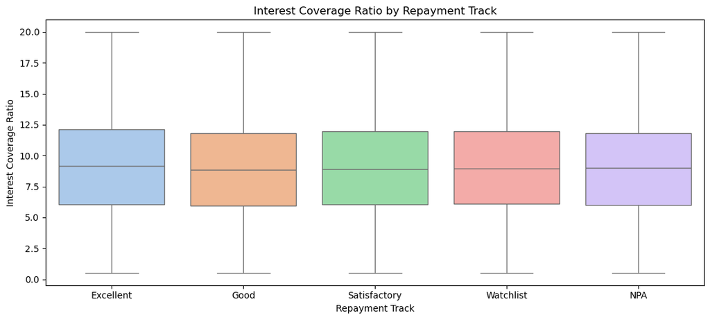

```python
# Chart 3: Boxplot — Interest Coverage Ratio by Repayment Track
plt.figure(figsize=(11,5))
order_rt = ['Excellent','Good','Satisfactory','Watchlist','NPA']
sns.boxplot(data=data_df, x='Repayment_Track', y='Interest_Coverage_Ratio', order=order_rt, palette='pastel')

plt.title("Interest Coverage Ratio by Repayment Track")
plt.xlabel("Repayment Track")
plt.ylabel("Interest Coverage Ratio")
plt.tight_layout()
plt.show()
```

#### Chart 4: Grouped or stacked bar chart combining two categorical features

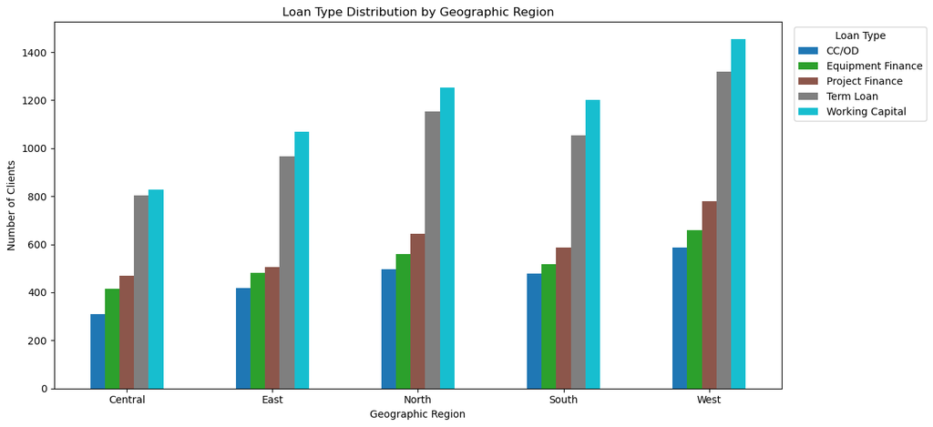

```python
# Chart 4: Grouped Bar — Loan Type by Geographic Region
pivot = data_df.groupby(['Geographic_Region','Loan_Type']).size().unstack(fill_value=0)
fig, ax = plt.subplots(figsize=(13, 6))
pivot.plot(kind='bar', ax=ax, colormap='tab10', rot=0)
ax.set_title('Loan Type Distribution by Geographic Region')
ax.set_xlabel('Geographic Region')
ax.set_ylabel('Number of Clients')
ax.legend(title='Loan Type', bbox_to_anchor=(1.01,1), loc='upper left')
plt.tight_layout()
plt.show()
```

#### Chart 5: Heatmap of average numerical features grouped by a categorical column

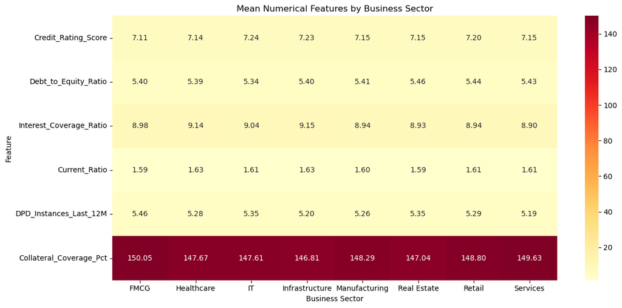

```python
# Chart 5: Heatmap — Mean Numerical Features by Business Sector
sector_means = data_df.groupby('Business_Sector')[
    ['Credit_Rating_Score','Debt_to_Equity_Ratio','Interest_Coverage_Ratio',
     'Current_Ratio','DPD_Instances_Last_12M','Collateral_Coverage_Pct']
].mean()
plt.figure(figsize=(13, 6))
sns.heatmap(sector_means.T, annot=True, fmt='.2f', cmap='YlOrRd')
plt.title('Mean Numerical Features by Business Sector')
plt.xlabel('Business Sector')
plt.ylabel('Feature')
plt.tight_layout()
plt.show()
```

#### Chart 6: Chart of your own choice — must reveal an insight not covered in Charts 1–5

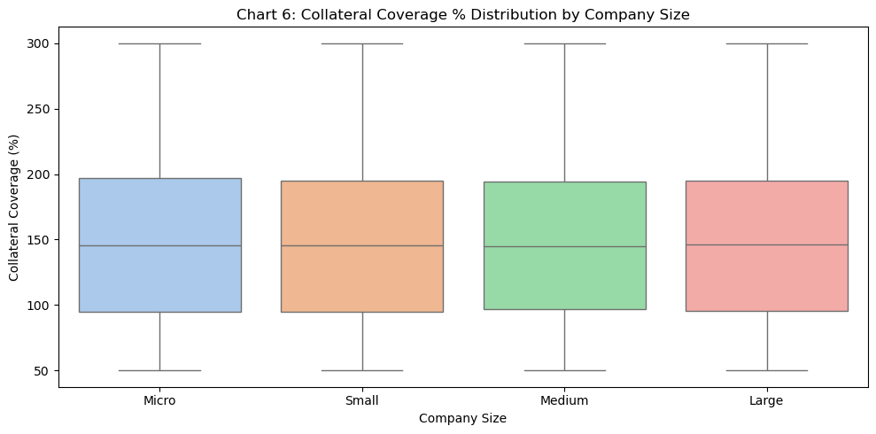

```python
# Chart 6: Violin Plot — Collateral Coverage % by Company Size
plt.figure(figsize=(10, 5))
order_sz = ['Micro','Small','Medium','Large']
sns.boxplot(data=data_df, x='Company_Size', y='Collateral_Coverage_Pct',
               order=order_sz, palette='pastel')
plt.title('Chart 6: Collateral Coverage % Distribution by Company Size')
plt.xlabel('Company Size')
plt.ylabel('Collateral Coverage (%)')
plt.tight_layout()
plt.show()
```

## Task 5 — Data Pre-Processing [3 Marks]

- Impute missing values in numerical columns using median imputation.
- Impute missing values in categorical columns using mode imputation.
- Encoding:
  1. Apply Label Encoding to any ordinal categorical features (e.g., tier, band, experience level — encode in logical ascending order).
  2. Apply One-Hot Encoding (pd.get_dummies) to all remaining nominal categorical features.
- Scale all numerical features using StandardScaler from sklearn.preprocessing.
- Confirm zero null values remain in the processed dataframe before proceeding to clustering.

#### Impute missing values in numerical columns using median imputation.

```python
num_cols
```

```
['Years_In_Business',
 'Annual_Revenue_INR_Cr',
 'Loan_Outstanding_INR_Cr',
 'Debt_to_Equity_Ratio',
 'Interest_Coverage_Ratio',
 'Current_Ratio',
 'DPD_Instances_Last_12M',
 'Credit_Rating_Score',
 'New_Loan_Requests_Last_2Y',
 'Collateral_Coverage_Pct']
```

```python
for col in num_cols:
    data_df[col] = data_df[col].fillna(data_df[col].median())
```

#### Impute missing values in categorical columns using mode imputation.

```python
for col in cat_cols:
    data_df[col] = data_df[col].fillna(data_df[col].mode()[0])
```

```python
data_df.isnull().sum()
```

```
ClientID                     0
Years_In_Business            0
Annual_Revenue_INR_Cr        0
Loan_Outstanding_INR_Cr      0
Debt_to_Equity_Ratio         0
Interest_Coverage_Ratio      0
Current_Ratio                0
DPD_Instances_Last_12M       0
Credit_Rating_Score          0
New_Loan_Requests_Last_2Y    0
Collateral_Coverage_Pct      0
Business_Sector              0
Company_Size                 0
Loan_Type                    0
Repayment_Track              0
Geographic_Region            0
dtype: int64
```

### Encoding

```python
# Clean working copy
encoded_df = data_df.copy()
encoded_df = encoded_df.drop("ClientID", axis = 1)
```

#### Apply Label Encoding to any ordinal categorical features (e.g., tier, band, experience level — encode in logical ascending order).

```python
# Repayment_Track : NPA=0 (highest risk) → Excellent=4 (lowest risk)
# Company_Size    : Micro=0              → Large=3

repayment_order    = {'Excellent':4,'Good':3,'Satisfactory':2,'Watchlist':1,'NPA':0}
company_size_order = {'Micro':0,'Small':1,'Medium':2,'Large':3}

encoded_df['Repayment_Track_Enc'] = encoded_df['Repayment_Track'].map(repayment_order)
encoded_df['Company_Size_Enc']    = encoded_df['Company_Size'].map(company_size_order)
encoded_df = encoded_df.drop(columns=['Repayment_Track','Company_Size'])
```

#### Apply One-Hot Encoding (pd.get_dummies) to all remaining nominal categorical features.

```python
col_to_encode = encoded_df.select_dtypes(include = 'object').columns    # Create a list of column names of all object data columns
col_to_encode
```

```
Index(['Business_Sector', 'Loan_Type', 'Geographic_Region'], dtype='object')
```

```python
# Create dummies for the above columns

encoded_df = pd.get_dummies(encoded_df, columns = col_to_encode, drop_first = True)
encoded_df.head()
```

|  | Years_In_Business | Annual_Revenue_INR_Cr | Loan_Outstanding_INR_Cr | Debt_to_Equity_Ratio | Interest_Coverage_Ratio | Current_Ratio | DPD_Instances_Last_12M | Credit_Rating_Score | New_Loan_Requests_Last_2Y | Collateral_Coverage_Pct | ... | Business_Sector_Retail | Business_Sector_Services | Loan_Type_Equipment Finance | Loan_Type_Project Finance | Loan_Type_Term Loan | Loan_Type_Working Capital | Geographic_Region_East | Geographic_Region_North | Geographic_Region_South | Geographic_Region_West |
| --- | --- | --- | --- | --- | --- | --- | --- | --- | --- | --- | --- | --- | --- | --- | --- | --- | --- | --- | --- | --- | --- |
| 0 | 7.35 | 3707.81 | 196.44 | 3.24 | 9.47 | 0.85 | 0.0 | 7.25 | 3 | 110.48 | ... | False | False | False | False | True | False | False | False | False | True |
| 1 | 20.71 | 765.38 | 349.29 | 5.53 | 8.96 | 0.37 | 4.0 | 3.55 | 5 | 203.57 | ... | False | False | False | False | False | True | False | True | False | False |
| 2 | 1.00 | 607.78 | 82.69 | 3.75 | 5.52 | 2.03 | 7.0 | 8.60 | 0 | 111.07 | ... | False | True | False | False | False | True | False | False | False | True |
| 3 | 2.52 | 751.05 | 166.79 | 7.24 | 14.68 | 1.43 | 6.0 | 6.56 | 0 | 182.13 | ... | False | False | False | False | True | False | False | False | True | False |
| 4 | 1.00 | 904.69 | 117.65 | 2.97 | 10.07 | 2.78 | 6.0 | 10.00 | 1 | 96.64 | ... | False | True | False | True | False | False | True | False | False | False |

5 rows × 27 columns

## Task 6 — Feature Engineering

- Create at least 2 new features derived from existing columns.
- In a markdown cell, state: (a) the formula used, and (b) the business rationale for each feature.
- Plot the distribution of each new feature and write a 2-sentence interpretation.
- Include the engineered features in the scaled feature matrix used for clustering.

### Feature 1: Revenue_per_Loan

- Formula: Annual_Revenue_INR_Cr / Loan_Outstanding_INR_Cr
- Rationale: Revenue-to-debt efficiency. High (>10) = lean, low-leverage. Low (<2) = over-borrowed, earnings may not service debt.

```python
data_df['Revenue_per_Loan'] = data_df['Annual_Revenue_INR_Cr'] / data_df['Loan_Outstanding_INR_Cr']
```

### Feature 2: Financial_Stress_Index

- Formula: (Debt_to_Equity_Ratio x DPD_Instances_Last_12M) / (Credit_Rating_Score + 1)
- Rationale: Composite stress indicator combining leverage, delinquency, and credit quality. Near-zero = healthy; high = financially distressed.

```python
data_df['Financial_Stress_Index'] = (data_df['Debt_to_Equity_Ratio'] * data_df['DPD_Instances_Last_12M']) / (data_df['Credit_Rating_Score'] + 1)
```

```python
data_df[['Revenue_per_Loan','Financial_Stress_Index']].head()
```

|  | Revenue_per_Loan | Financial_Stress_Index |
| --- | --- | --- |
| 0 | 18.875025 | 0.000000 |
| 1 | 2.191245 | 4.861538 |
| 2 | 7.350103 | 2.734375 |
| 3 | 4.502968 | 5.746032 |
| 4 | 7.689673 | 1.620000 |

[figure not shown]

```python
sns.histplot(data_df['Revenue_per_Loan'], kde=True)
plt.title('Revenue per Loan Distribution')
plt.xlabel('Revenue / Loan Outstanding')
plt.ylabel('Frequency')

plt.tight_layout()
plt.show()
```

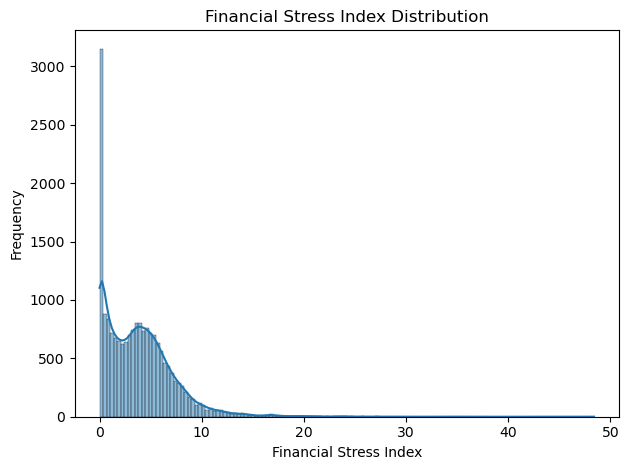

```python
sns.histplot(data_df['Financial_Stress_Index'], kde=True)
plt.title('Financial Stress Index Distribution')
plt.xlabel('Financial Stress Index')
plt.ylabel('Frequency')

plt.tight_layout()
plt.show()
```

**Financial Stress Index Distribution:** The index is strongly right-skewed and concentrated near zero, indicating that the majority of Tata Capital's clients are in relatively healthy financial condition with low combined leverage-delinquency stress. However, a meaningful tail of clients with high Financial Stress Index values (above 10) represents the segment requiring urgent credit monitoring and early intervention.

## Scaling Data

```python
numeric_data = data_df.drop(cat_cols, axis = 1)
```

```python
# importing the StandardScaler Module

from sklearn.preprocessing import StandardScaler
```

```python
# Creating an object for the StandardScaler function
# Instanciating

scaler = StandardScaler()
```

```python
scaled_df = pd.DataFrame(scaler.fit_transform(numeric_data), columns=numeric_data.columns)
```

```python
scaled_df.head()
```

|  | Years_In_Business | Annual_Revenue_INR_Cr | Loan_Outstanding_INR_Cr | Debt_to_Equity_Ratio | Interest_Coverage_Ratio | Current_Ratio | DPD_Instances_Last_12M | Credit_Rating_Score | New_Loan_Requests_Last_2Y | Collateral_Coverage_Pct | Revenue_per_Loan | Financial_Stress_Index |
| --- | --- | --- | --- | --- | --- | --- | --- | --- | --- | --- | --- | --- |
| 0 | -0.716802 | 1.743832 | 0.387110 | -1.256072 | 0.119206 | -0.929848 | -1.384498 | 0.034443 | 0.162608 | -0.573960 | -0.202973 | -1.113553 |
| 1 | 0.478199 | -0.595685 | 1.980481 | 0.069058 | -0.005752 | -1.517746 | -0.332742 | -1.577955 | 1.177406 | 0.839324 | -0.207189 | 0.315330 |
| 2 | -1.284785 | -0.720992 | -0.798667 | -0.960956 | -0.848603 | 0.515403 | 0.456075 | 0.622750 | -1.359589 | -0.565003 | -0.205885 | -0.309877 |
| 3 | -1.148827 | -0.607078 | 0.078026 | 1.058565 | 1.395732 | -0.219470 | 0.193136 | -0.266247 | -1.359589 | 0.513824 | -0.206605 | 0.575297 |
| 4 | -1.284785 | -0.484920 | -0.434229 | -1.412310 | 0.266214 | 1.433994 | 0.193136 | 1.232847 | -0.852190 | -0.784078 | -0.205800 | -0.637409 |

```python
s1 = scaled_df.isnull().sum()   # Creates a series of count of missing values for each column
s2 = scaled_df.isnull().sum() / scaled_df.shape[0] * 100 # Creates a series of percentage of missing values for each column


# Display both the output together

missing = pd.concat([s1, s2], axis=1)
missing.columns = ["Count of Missing Values", "Percentage of Missing Values"]

print('Total Count of Missing Values in the data is:', scaled_df.isnull().sum().sum())

missing
```

```
Total Count of Missing Values in the data is: 0
```

|  | Count of Missing Values | Percentage of Missing Values |
| --- | --- | --- |
| Years_In_Business | 0 | 0.0 |
| Annual_Revenue_INR_Cr | 0 | 0.0 |
| Loan_Outstanding_INR_Cr | 0 | 0.0 |
| Debt_to_Equity_Ratio | 0 | 0.0 |
| Interest_Coverage_Ratio | 0 | 0.0 |
| Current_Ratio | 0 | 0.0 |
| DPD_Instances_Last_12M | 0 | 0.0 |
| Credit_Rating_Score | 0 | 0.0 |
| New_Loan_Requests_Last_2Y | 0 | 0.0 |
| Collateral_Coverage_Pct | 0 | 0.0 |
| Revenue_per_Loan | 0 | 0.0 |
| Financial_Stress_Index | 0 | 0.0 |

```python
scaled_df.describe().T
```

|  | count | mean | std | min | 25% | 50% | 75% | max |
| --- | --- | --- | --- | --- | --- | --- | --- | --- |
| Years_In_Business | 19000.0 | -5.646945e-17 | 1.000026 | -1.284785 | -0.911795 | -0.072789 | 0.752799 | 2.203617 |
| Annual_Revenue_INR_Cr | 19000.0 | -1.832452e-17 | 1.000026 | -1.203441 | -0.823655 | -0.613900 | 1.210479 | 2.089262 |
| Loan_Outstanding_INR_Cr | 19000.0 | 1.215402e-17 | 1.000026 | -1.659619 | -0.724784 | -0.190819 | 0.873409 | 2.632007 |
| Debt_to_Equity_Ratio | 19000.0 | 1.488400e-16 | 1.000026 | -3.130928 | -0.677413 | -0.017741 | 0.647717 | 2.655665 |
| Interest_Coverage_Ratio | 19000.0 | 2.509338e-16 | 1.000026 | -2.078577 | -0.691793 | -0.005752 | 0.694990 | 2.699211 |
| Current_Ratio | 19000.0 | 2.241949e-16 | 1.000026 | -1.603481 | -0.758377 | -0.023504 | 0.699121 | 4.018298 |
| DPD_Instances_Last_12M | 19000.0 | -4.197812e-17 | 1.000026 | -1.384498 | -0.858620 | -0.069803 | 0.981953 | 1.770770 |
| Credit_Rating_Score | 19000.0 | -3.704171e-16 | 1.000026 | -2.689202 | -0.688957 | 0.121600 | 0.884220 | 1.232847 |
| New_Loan_Requests_Last_2Y | 19000.0 | -1.533276e-17 | 1.000026 | -1.359589 | -0.852190 | 0.162608 | 0.670007 | 2.699604 |
| Collateral_Coverage_Pct | 19000.0 | 1.438849e-16 | 1.000026 | -1.492162 | -0.802220 | -0.043808 | 0.708152 | 2.303315 |
| Revenue_per_Loan | 19000.0 | 1.234101e-17 | 1.000026 | -0.207742 | -0.206959 | -0.206069 | -0.203880 | 6.581153 |
| Financial_Stress_Index | 19000.0 | 4.300653e-17 | 1.000026 | -1.113553 | -0.821904 | -0.109476 | 0.534014 | 13.111972 |

## Task 8 — Identifying Optimal K [3 Marks]

#### Method A — Elbow Method (WSS / Inertia):

- Calculate inertia for K = 2 through K = 10 (use random_state = 42 each time).
- Plot the WSS curve; clearly mark and annotate the elbow point.

#### Method B — Silhouette Score:

- Calculate average silhouette score for K = 2 through K = 10.
- Plot the silhouette scores; identify the K that maximises the score.
- In a markdown cell, state your final K and justify in at least 3 sentences — reconciling the evidence from both methods.

### Method A — Elbow Method (WSS / Inertia)

```python
wss =[]

for i in range(2,11):
    KM = KMeans(n_clusters=i,random_state=42)
    KM.fit(scaled_df)
    wss.append(KM.inertia_)

wss
```

```
[182792.83739432122,
 151315.43153977892,
 124017.41116342282,
 108131.9340383673,
 103699.61625267602,
 100760.71844873585,
 98547.3627862994,
 93938.5819061842,
 90862.53218838084]
```

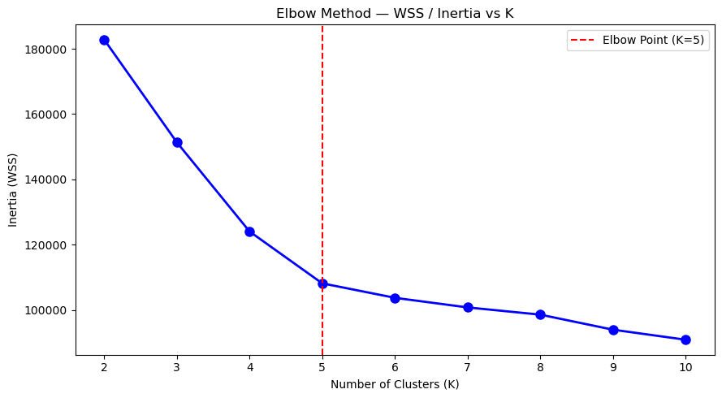

```python
plt.figure(figsize = (9, 5))

plt.plot(range(2,11), wss,'bo-', markersize=8, linewidth=2)

plt.axvline(x=5, color='red', linestyle='--', linewidth=1.5, label='Elbow Point (K=5)')
plt.title('Elbow Method — WSS / Inertia vs K')
plt.xlabel('Number of Clusters (K)')
plt.ylabel('Inertia (WSS)')
plt.xticks(range(2,11))
plt.legend()
plt.tight_layout()
plt.show()
```

### Method B — Silhouette Score

```python
from sklearn.metrics import silhouette_samples, silhouette_score
```

```python
sil_scores = []

for k in range(2,11):
    km     = KMeans(n_clusters=k, random_state=42)
    labels = km.fit_predict(scaled_df)
    score  = silhouette_score(scaled_df, labels, random_state=42)
    sil_scores.append(score)

sil_scores
```

```
[0.21299738646581295,
 0.2473277226865696,
 0.2971503381816191,
 0.31467426161454426,
 0.22124921701549624,
 0.1584103514153201,
 0.1563542831370912,
 0.15131974943966003,
 0.1466257184103288]
```

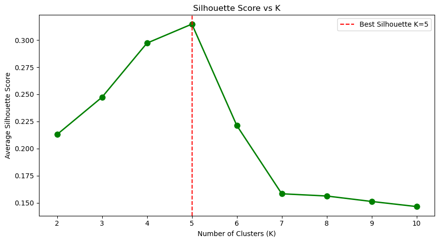

```python
plt.figure(figsize = (9, 5))
best_k_sil = range(2,11)[np.argmax(sil_scores)]

plt.plot(range(2,11), sil_scores,'go-', markersize=8, linewidth=2)

plt.axvline(x=best_k_sil, color='red', linestyle='--', linewidth=1.5, label=f'Best Silhouette K={best_k_sil}')
plt.title('Silhouette Score vs K')
plt.xlabel('Number of Clusters (K)')
plt.ylabel('Average Silhouette Score')
plt.xticks(range(2,11))
plt.legend()
plt.tight_layout()
plt.show()
```

### Optimal K Selection — Final Justification

**Final K Selected: 5**

The **Elbow Method (WSS/Inertia)** shows a clear bend in the curve between K=4 and K=5 (inertia drops from ~151,315 at K=3 to ~124,017 at K=4 to ~108,132 at K=5), after which the decline flattens considerably — from K=5 onward the curve descends only gradually, indicating diminishing gains in cluster compactness.

The **Silhouette Score** provides strong corroborating evidence: the average silhouette peaks at **K=5 (≈0.315)**, the highest value across the entire K=2–10 range, confirming that at K=5 clusters are most internally cohesive and well-separated from each other. Scores drop noticeably beyond K=5 (falling to ~0.221 at K=6 and continuing to decline), ruling out higher values of K.

Reconciling both methods, **K=5 is the clear optimal choice.**

## Task 7 — K-Means Clustering Model

- Select the features to include in clustering and justify your selection in a markdown cell.
- Fit a KMeans model (n_clusters = K, random_state = 42) using the optimal K from Task 8.
- Assign cluster labels back to the original (unscaled) dataframe as a new column named Cluster.
- Display the number of entities assigned to each cluster.
- Show 5 sample rows from each cluster to confirm correct label assignment.

#### Select the features to include in clustering and justify your selection in a markdown cell.

```python
features_to_include = data_df.select_dtypes(include='number').columns.to_list()
features_to_include
```

```
['Years_In_Business',
 'Annual_Revenue_INR_Cr',
 'Loan_Outstanding_INR_Cr',
 'Debt_to_Equity_Ratio',
 'Interest_Coverage_Ratio',
 'Current_Ratio',
 'DPD_Instances_Last_12M',
 'Credit_Rating_Score',
 'New_Loan_Requests_Last_2Y',
 'Collateral_Coverage_Pct',
 'Revenue_per_Loan',
 'Financial_Stress_Index']
```

#### Feature Selection Justification

All **12 numerical features** available in the processed dataframe are selected for clustering, including the two engineered features:

`Years_In_Business`, `Annual_Revenue_INR_Cr`, `Loan_Outstanding_INR_Cr`, `Debt_to_Equity_Ratio`, `Interest_Coverage_Ratio`, `Current_Ratio`, `DPD_Instances_Last_12M`, `Credit_Rating_Score`, `New_Loan_Requests_Last_2Y`, `Collateral_Coverage_Pct`, `Revenue_per_Loan`, `Financial_Stress_Index`

**Why numerical only?** KMeans uses Euclidean distance, which is distorted by binary OHE dummy columns. Including 20+ one-hot dummies would flood the distance metric and obscure meaningful financial signal.

#### KMeans with K = 5 (Optimal K according to the Silhoutte Score)

```python
# Create K Means cluster and store the result in the object k_means

k_means = KMeans(n_clusters=5, random_state=42)
```

```python
# Fit K means on the scaled_df

k_means.fit(scaled_df)
```

```
KMeans(n_clusters=5, random_state=42)
```

```python
# Get the labels
labels = k_means.labels_
```

#### Assign cluster labels back to the original (unscaled) dataframe as a new column named Cluster.

```python
data_df["Cluster"] = labels
data_df.head()
```

|  | ClientID | Years_In_Business | Annual_Revenue_INR_Cr | Loan_Outstanding_INR_Cr | Debt_to_Equity_Ratio | Interest_Coverage_Ratio | Current_Ratio | DPD_Instances_Last_12M | Credit_Rating_Score | New_Loan_Requests_Last_2Y | Collateral_Coverage_Pct | Business_Sector | Company_Size | Loan_Type | Repayment_Track | Geographic_Region | Revenue_per_Loan | Financial_Stress_Index | Cluster |
| --- | --- | --- | --- | --- | --- | --- | --- | --- | --- | --- | --- | --- | --- | --- | --- | --- | --- | --- | --- |
| 0 | TAC011791 | 7.35 | 3707.81 | 196.44 | 3.24 | 9.47 | 0.85 | 0.0 | 7.25 | 3 | 110.48 | Healthcare | Small | Term Loan | Satisfactory | West | 18.875025 | 0.000000 | 3 |
| 1 | TAC002036 | 20.71 | 765.38 | 349.29 | 5.53 | 8.96 | 0.37 | 4.0 | 3.55 | 5 | 203.57 | Healthcare | Medium | Working Capital | Watchlist | North | 2.191245 | 4.861538 | 1 |
| 2 | TAC008728 | 1.00 | 607.78 | 82.69 | 3.75 | 5.52 | 2.03 | 7.0 | 8.60 | 0 | 111.07 | Services | Small | Working Capital | Excellent | West | 7.350103 | 2.734375 | 2 |
| 3 | TAC007765 | 2.52 | 751.05 | 166.79 | 7.24 | 14.68 | 1.43 | 6.0 | 6.56 | 0 | 182.13 | Real Estate | Large | Term Loan | Good | South | 4.502968 | 5.746032 | 2 |
| 4 | TAC003327 | 1.00 | 904.69 | 117.65 | 2.97 | 10.07 | 2.78 | 6.0 | 10.00 | 1 | 96.64 | Services | Small | Project Finance | Satisfactory | East | 7.689673 | 1.620000 | 2 |

#### Display the number of entities assigned to each cluster.

```python
cluster_counts = data_df.Cluster.value_counts().sort_index()
print("Cluster Label Distribution:")
for c, cnt in cluster_counts.items():
    print(f"  Cluster {c}: {cnt:,} clients ({cnt/len(data_df)*100:.1f}%)")
```

```
Cluster Label Distribution:
  Cluster 0: 3,179 clients (16.7%)
  Cluster 1: 2,572 clients (13.5%)
  Cluster 2: 7,573 clients (39.9%)
  Cluster 3: 4,937 clients (26.0%)
  Cluster 4: 739 clients (3.9%)
```

#### Show 5 sample rows from each cluster to confirm correct label assignment.

```python
for cluster in sorted(data_df['Cluster'].unique()):

    print(f"\n===== Cluster {cluster} =====")

    display(data_df[data_df['Cluster'] == cluster].head(5))
```

```
===== Cluster 0 =====
```

|  | ClientID | Years_In_Business | Annual_Revenue_INR_Cr | Loan_Outstanding_INR_Cr | Debt_to_Equity_Ratio | Interest_Coverage_Ratio | Current_Ratio | DPD_Instances_Last_12M | Credit_Rating_Score | New_Loan_Requests_Last_2Y | Collateral_Coverage_Pct | Business_Sector | Company_Size | Loan_Type | Repayment_Track | Geographic_Region | Revenue_per_Loan | Financial_Stress_Index | Cluster |
| --- | --- | --- | --- | --- | --- | --- | --- | --- | --- | --- | --- | --- | --- | --- | --- | --- | --- | --- | --- |
| 29 | TAC015850 | 37.74 | 1719.64 | 18.03 | 7.37 | 6.03 | 1.41 | 3.0 | 4.68 | 8 | 104.10 | Manufacturing | Medium | Project Finance | Watchlist | Central | 95.376595 | 3.892606 | 0 |
| 34 | TAC016042 | 20.10 | 2142.98 | 30.14 | 5.65 | 3.36 | 0.30 | 0.0 | 6.97 | 4 | 196.66 | Infrastructure | Medium | CC/OD | Satisfactory | North | 71.100863 | 0.000000 | 0 |
| 41 | TAC013204 | 5.16 | 548.07 | 344.05 | 6.77 | 8.96 | 0.76 | 5.0 | 1.00 | 0 | 115.27 | Infrastructure | Small | Term Loan | Excellent | East | 1.592995 | 16.925000 | 0 |
| 58 | TAC003015 | 15.77 | 1883.82 | 12.52 | 8.53 | 2.10 | 1.42 | 5.0 | 5.03 | 4 | 133.19 | IT | Micro | Working Capital | NPA | South | 150.464856 | 7.072968 | 0 |
| 59 | TAC004741 | 26.92 | 815.53 | 51.63 | 6.40 | 4.92 | 2.71 | 3.0 | 6.19 | 4 | 111.95 | IT | Small | Working Capital | Good | South | 15.795661 | 2.670376 | 0 |

```
===== Cluster 1 =====
```

|  | ClientID | Years_In_Business | Annual_Revenue_INR_Cr | Loan_Outstanding_INR_Cr | Debt_to_Equity_Ratio | Interest_Coverage_Ratio | Current_Ratio | DPD_Instances_Last_12M | Credit_Rating_Score | New_Loan_Requests_Last_2Y | Collateral_Coverage_Pct | Business_Sector | Company_Size | Loan_Type | Repayment_Track | Geographic_Region | Revenue_per_Loan | Financial_Stress_Index | Cluster |
| --- | --- | --- | --- | --- | --- | --- | --- | --- | --- | --- | --- | --- | --- | --- | --- | --- | --- | --- | --- |
| 1 | TAC002036 | 20.71 | 765.38 | 349.29 | 5.53 | 8.96 | 0.37 | 4.0 | 3.55 | 5 | 203.57 | Healthcare | Medium | Working Capital | Watchlist | North | 2.191245 | 4.861538 | 1 |
| 5 | TAC014597 | 3.02 | 662.54 | 284.40 | 4.50 | 6.22 | 1.26 | 5.0 | 1.93 | 3 | 122.61 | Services | Medium | Equipment Finance | Good | Central | 2.329606 | 7.679181 | 1 |
| 7 | TAC006196 | 11.37 | 413.05 | 311.21 | 4.62 | 0.50 | 0.97 | 4.0 | 6.86 | 7 | 139.74 | Real Estate | Small | Equipment Finance | Excellent | North | 1.327239 | 2.351145 | 1 |
| 17 | TAC013116 | 22.44 | 888.04 | 237.83 | 6.81 | 1.29 | 0.37 | 3.0 | 6.33 | 5 | 135.42 | FMCG | Small | Working Capital | Excellent | Central | 3.733928 | 2.787176 | 1 |
| 40 | TAC002088 | 1.00 | 652.42 | 297.65 | 5.90 | 1.64 | 1.68 | 0.0 | 5.95 | 2 | 238.58 | Services | Micro | Project Finance | Satisfactory | East | 2.191903 | 0.000000 | 1 |

```
===== Cluster 2 =====
```

|  | ClientID | Years_In_Business | Annual_Revenue_INR_Cr | Loan_Outstanding_INR_Cr | Debt_to_Equity_Ratio | Interest_Coverage_Ratio | Current_Ratio | DPD_Instances_Last_12M | Credit_Rating_Score | New_Loan_Requests_Last_2Y | Collateral_Coverage_Pct | Business_Sector | Company_Size | Loan_Type | Repayment_Track | Geographic_Region | Revenue_per_Loan | Financial_Stress_Index | Cluster |
| --- | --- | --- | --- | --- | --- | --- | --- | --- | --- | --- | --- | --- | --- | --- | --- | --- | --- | --- | --- |
| 2 | TAC008728 | 1.00 | 607.78 | 82.69 | 3.75 | 5.52 | 2.03 | 7.0 | 8.60 | 0 | 111.07 | Services | Small | Working Capital | Excellent | West | 7.350103 | 2.734375 | 2 |
| 3 | TAC007765 | 2.52 | 751.05 | 166.79 | 7.24 | 14.68 | 1.43 | 6.0 | 6.56 | 0 | 182.13 | Real Estate | Large | Term Loan | Good | South | 4.502968 | 5.746032 | 2 |
| 4 | TAC003327 | 1.00 | 904.69 | 117.65 | 2.97 | 10.07 | 2.78 | 6.0 | 10.00 | 1 | 96.64 | Services | Small | Project Finance | Satisfactory | East | 7.689673 | 1.620000 | 2 |
| 8 | TAC014638 | 1.00 | 501.98 | 75.44 | 8.66 | 11.11 | 2.09 | 5.0 | 5.80 | 2 | 163.58 | Services | Medium | Term Loan | Good | West | 6.654030 | 6.367647 | 2 |
| 12 | TAC001524 | 4.82 | 172.88 | 64.62 | 3.16 | 9.60 | 0.87 | 10.0 | 9.94 | 2 | 99.48 | IT | Large | Equipment Finance | Good | North | 2.675333 | 2.888483 | 2 |

```
===== Cluster 3 =====
```

|  | ClientID | Years_In_Business | Annual_Revenue_INR_Cr | Loan_Outstanding_INR_Cr | Debt_to_Equity_Ratio | Interest_Coverage_Ratio | Current_Ratio | DPD_Instances_Last_12M | Credit_Rating_Score | New_Loan_Requests_Last_2Y | Collateral_Coverage_Pct | Business_Sector | Company_Size | Loan_Type | Repayment_Track | Geographic_Region | Revenue_per_Loan | Financial_Stress_Index | Cluster |
| --- | --- | --- | --- | --- | --- | --- | --- | --- | --- | --- | --- | --- | --- | --- | --- | --- | --- | --- | --- |
| 0 | TAC011791 | 7.35 | 3707.81 | 196.44 | 3.24 | 9.47 | 0.85 | 0.0 | 7.25 | 3 | 110.48 | Healthcare | Small | Term Loan | Satisfactory | West | 18.875025 | 0.000000 | 3 |
| 6 | TAC008432 | 26.57 | 3145.56 | 211.61 | 4.94 | 12.69 | 1.83 | 4.0 | 8.11 | 3 | 85.12 | Healthcare | Micro | Working Capital | Good | West | 14.864893 | 2.169045 | 3 |
| 9 | TAC006000 | 14.06 | 3185.09 | 235.45 | 3.69 | 12.32 | 1.63 | 3.0 | 9.14 | 3 | 119.86 | Infrastructure | Small | Term Loan | Excellent | East | 13.527670 | 1.091716 | 3 |
| 10 | TAC014385 | 20.14 | 3668.93 | 245.50 | 7.01 | 11.02 | 2.97 | 0.0 | 8.40 | 2 | 50.00 | Infrastructure | Large | Term Loan | Good | North | 14.944725 | 0.000000 | 3 |
| 11 | TAC007593 | 32.08 | 3608.38 | 266.15 | 4.12 | 12.29 | 1.96 | 2.0 | 6.21 | 1 | 50.70 | Real Estate | Small | Working Capital | Excellent | North | 13.557693 | 1.142857 | 3 |

```
===== Cluster 4 =====
```

|  | ClientID | Years_In_Business | Annual_Revenue_INR_Cr | Loan_Outstanding_INR_Cr | Debt_to_Equity_Ratio | Interest_Coverage_Ratio | Current_Ratio | DPD_Instances_Last_12M | Credit_Rating_Score | New_Loan_Requests_Last_2Y | Collateral_Coverage_Pct | Business_Sector | Company_Size | Loan_Type | Repayment_Track | Geographic_Region | Revenue_per_Loan | Financial_Stress_Index | Cluster |
| --- | --- | --- | --- | --- | --- | --- | --- | --- | --- | --- | --- | --- | --- | --- | --- | --- | --- | --- | --- |
| 39 | TAC015321 | 36.82 | 2195.61 | 0.1 | 7.03 | 7.00 | 2.50 | 3.0 | 6.24 | 2 | 58.84 | Real Estate | Medium | Working Capital | Good | South | 21956.1 | 2.912983 | 4 |
| 69 | TAC014047 | 35.35 | 2036.59 | 0.1 | 9.01 | 8.10 | 1.49 | 6.0 | 7.05 | 0 | 188.33 | Services | Medium | Term Loan | Good | East | 20365.9 | 6.715528 | 4 |
| 113 | TAC001465 | 33.11 | 1972.06 | 0.1 | 5.38 | 3.84 | 1.07 | 5.0 | 5.79 | 2 | 198.24 | Healthcare | Medium | Term Loan | Good | South | 19720.6 | 3.961708 | 4 |
| 169 | TAC018299 | 24.92 | 1752.93 | 0.1 | 6.66 | 5.97 | 1.38 | 5.0 | 4.28 | 2 | 50.00 | Manufacturing | Micro | Working Capital | Satisfactory | Central | 17529.3 | 6.306818 | 4 |
| 247 | TAC013114 | 29.99 | 1738.68 | 0.1 | 8.01 | 0.50 | 0.42 | 7.0 | 6.34 | 1 | 50.00 | Healthcare | Small | Term Loan | NPA | West | 17386.8 | 7.638965 | 4 |

## Task 9 — Cluster Profiles

- Compute the mean of all numerical features grouped by Cluster — use the original unscaled dataframe.
- Create a heatmap visualising cluster-wise mean values for the key numerical features.
- Show the mode (most common value) of categorical features per cluster.
- Create a grouped bar chart comparing at least 3 key features across clusters.
- Write a 3–5 sentence descriptive profile for each cluster and assign a memorable business label.

#### Mean numerical features per cluster (original unscaled data)

```python
cluster_profiles = data_df.groupby('Cluster')[features_to_include].mean().round(2)
cluster_profiles.T
```

| Cluster | 0 | 1 | 2 | 3 | 4 |
| --- | --- | --- | --- | --- | --- |
| Years_In_Business | 27.94 | 16.16 | 5.80 | 19.43 | 29.35 |
| Annual_Revenue_INR_Cr | 1652.16 | 579.55 | 499.61 | 3391.47 | 2039.17 |
| Loan_Outstanding_INR_Cr | 44.35 | 302.81 | 122.22 | 239.28 | 0.10 |
| Debt_to_Equity_Ratio | 7.07 | 5.34 | 5.27 | 4.35 | 7.03 |
| Interest_Coverage_Ratio | 5.55 | 5.54 | 9.40 | 12.79 | 6.10 |
| Current_Ratio | 1.30 | 1.01 | 1.78 | 1.91 | 1.23 |
| DPD_Instances_Last_12M | 4.92 | 2.04 | 8.87 | 1.54 | 5.89 |
| Credit_Rating_Score | 5.35 | 4.78 | 8.57 | 7.69 | 5.50 |
| New_Loan_Requests_Last_2Y | 2.72 | 4.44 | 2.20 | 2.41 | 3.09 |
| Collateral_Coverage_Pct | 144.15 | 219.57 | 159.80 | 97.00 | 142.55 |
| Revenue_per_Loan | 145.85 | 1.98 | 4.58 | 14.53 | 20355.21 |
| Financial_Stress_Index | 6.00 | 2.15 | 5.03 | 0.81 | 7.13 |

#### Cluster Profile Heatmap

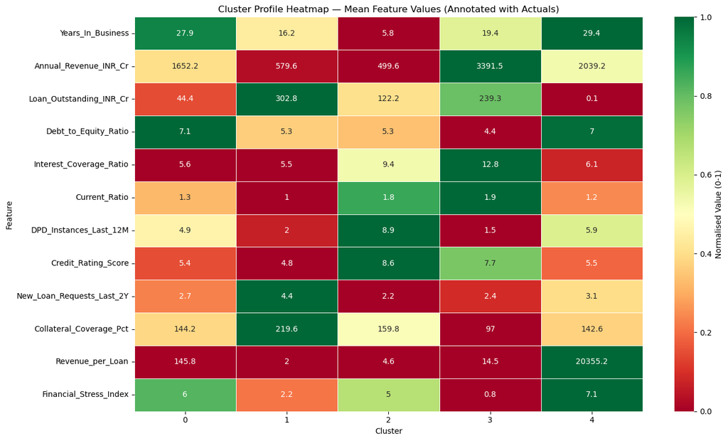

```python
profile_norm = ((cluster_profiles - cluster_profiles.min()) /
                (cluster_profiles.max() - cluster_profiles.min()))

plt.figure(figsize=(14, 8))
sns.heatmap(profile_norm.T,
            annot=cluster_profiles.T.round(1), fmt='g',
            cmap='RdYlGn', linewidths=0.5,
            cbar_kws={'label': 'Normalised Value (0-1)'})
plt.title('Cluster Profile Heatmap — Mean Feature Values (Annotated with Actuals)')
plt.xlabel('Cluster')
plt.ylabel('Feature')
plt.tight_layout()
plt.show()
```

#### Mode of categorical features per cluster

```python
print("Most Frequent (Mode) Categorical Values per Cluster:\n")
for col in cat_cols:
    modes = data_df.groupby('Cluster')[col].agg(lambda x: x.mode()[0])
    print(f"  {col}:")
    for c, m in modes.items():
        print(f"    Cluster {c}: {m}")
    print()
```

```
Most Frequent (Mode) Categorical Values per Cluster:

  ClientID:
    Cluster 0: TAC000030
    Cluster 1: TAC000003
    Cluster 2: TAC000005
    Cluster 3: TAC000001
    Cluster 4: TAC000051

  Business_Sector:
    Cluster 0: Manufacturing
    Cluster 1: Manufacturing
    Cluster 2: Manufacturing
    Cluster 3: Manufacturing
    Cluster 4: Manufacturing

  Company_Size:
    Cluster 0: Small
    Cluster 1: Small
    Cluster 2: Small
    Cluster 3: Small
    Cluster 4: Small

  Loan_Type:
    Cluster 0: Working Capital
    Cluster 1: Working Capital
    Cluster 2: Working Capital
    Cluster 3: Working Capital
    Cluster 4: Term Loan

  Repayment_Track:
    Cluster 0: Good
    Cluster 1: Good
    Cluster 2: Good
    Cluster 3: Good
    Cluster 4: Good

  Geographic_Region:
    Cluster 0: West
    Cluster 1: West
    Cluster 2: West
    Cluster 3: West
    Cluster 4: South
```

**Categorical Mode Interpretation:** Manufacturing dominates as the primary sector and Small as the most common company size across all clusters, reflecting the broader portfolio composition. The key differentiator is Loan_Type — Clusters 0–3 are predominantly Working Capital borrowers, while Cluster 4 leans toward Term Loans, consistent with their historical long-term credit facilities now fully or nearly repaid. Geographic concentration in the West region across most clusters aligns with major commercial and industrial hubs (Mumbai, Pune), while Cluster 4's South region bias may reflect a concentration of mature infrastructure and manufacturing clients in that geography.

#### Grouped Bar — Key Financial Metrics Across Clusters

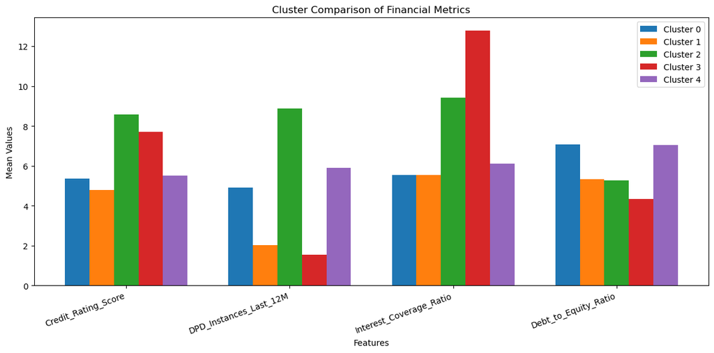

```python
features_plot = ['Credit_Rating_Score',
                 'DPD_Instances_Last_12M',
                 'Interest_Coverage_Ratio',
                 'Debt_to_Equity_Ratio']

x = np.arange(len(features_plot))
n_clusters = len(cluster_profiles)
width = 0.15

plt.figure(figsize=(12, 6))

for i in range(n_clusters):
    values = cluster_profiles.iloc[i][features_plot].values
    plt.bar(x + i*width, values, width, label=f'Cluster {i}')

plt.xticks(x + width*(n_clusters-1)/2, features_plot, rotation=20, ha='right')

plt.title('Cluster Comparison of Financial Metrics')
plt.xlabel('Features')
plt.ylabel('Mean Values')

plt.legend()
plt.tight_layout()
plt.show()
```

### Cluster Profiles — Summary Interpretation

Based on the mean values above, here is the interpretation of each cluster:

| Cluster | Business Label | Size | Avg Revenue (₹Cr) | Avg Loan (₹Cr) | Avg DPD | Credit Score | ICR |
| --- | --- | --- | --- | --- | --- | --- | --- |
| 0 | Seasoned Leveraged Survivors | 3,179 (16.7%) | 1,652 | 44 | 4.92 | 5.35 | 5.55 |
| 1 | High-Debt Emerging Risk | 2,572 (13.5%) | 580 | 303 | 2.04 | 4.78 | 5.54 |
| 2 | Stressed Young Borrowers | 7,573 (39.9%) | 500 | 122 | 8.87 | 8.57 | 9.40 |
| 3 | High-Revenue Prime Clients | 4,937 (26.0%) | 3,391 | 239 | 1.54 | 7.69 | 12.79 |
| 4 | Legacy Near-Zero Exposure | 739 (3.9%) | 2,039 | 0.10 | 5.89 | 5.50 | 6.10 |

**Cluster 0: "Seasoned Leveraged Survivors"**

- These are well-established businesses averaging ~28 years of operation, carrying a high Debt-to-Equity Ratio (~7.07) and a moderately elevated DPD (~4.92).
- Their Credit Rating (~5.35) and Interest Coverage Ratio (~5.55) sit below the portfolio average, while their Financial Stress Index (~6.00) signals meaningful financial strain.
- Despite their experience, their low outstanding loan (~₹44 Cr) and reasonable collateral coverage (~144%) indicate that prior debt has been partially paid down, but the residual leverage structure remains burdensome.
- These clients have survived decades but carry the accumulated weight of leverage — mature, resilient, yet financially stretched.

**Cluster 1: "High-Debt Emerging Risk"**

- Cluster 1 carries the highest average loan outstanding across all clusters (₹303 Cr) against relatively low revenues (~₹580 Cr), yielding the worst Revenue_per_Loan ratio (~1.98) in the portfolio.
- Their Interest Coverage (~5.54) barely exceeds a comfortable threshold, and their Debt-to-Equity (~5.34) adds additional leverage concern.
- The silver lining is the highest collateral coverage (~220%), suggesting substantial asset pledging as compensation for weak income-driven repayment capacity.
- With a relatively low DPD (~2.04), they are currently servicing debt, but their thin earnings buffer makes them vulnerable to any revenue shock — heavily leveraged borrowers operating on fragile repayment margins.

**Cluster 2: "Stressed Young Borrowers"**

- The portfolio's largest cluster (39.9%), Cluster 2 is defined by young businesses (~5.8 years) with the highest DPD instances (~8.87) — the clearest stress signal in the entire dataset.
- Paradoxically, they carry the highest Credit Rating Score (~8.57) and a healthy ICR (~9.40), suggesting these businesses have underlying operational viability but are experiencing acute short-term cash flow disruptions, possibly from rapid scaling or seasonal volatility.
- Their Financial Stress Index (~5.03) is elevated, and their Revenue_per_Loan (~4.58) is low.
- This cluster is the portfolio's most operationally volatile segment — young businesses with good fundamentals but severe payment discipline issues that demand immediate attention.

**Cluster 3: "High-Revenue Prime Clients"**

- Cluster 3 is unambiguously Tata Capital's most financially sound segment.
- With the highest average revenue (₹3,391 Cr), the lowest DPD (~1.54), the strongest ICR (~12.79), a healthy Current Ratio (~1.91), and the lowest Debt-to-Equity (~4.35), these clients represent textbook low-risk borrowers.
- Their Financial Stress Index (~0.81) is the lowest across all clusters, and their Credit Rating Score (~7.69) is strong.
- These are large, established corporates (avg ~19 years) that generate abundant cash flows and service all obligations comfortably — Tata Capital's anchor relationship portfolio and primary engine of stable fee income.

**Cluster 4: "Legacy Near-Zero Exposure"**

- The smallest but most distinctive cluster (739 clients), Cluster 4 is defined by near-complete loan repayment — average outstanding of just ₹0.10 Cr against revenues of ~₹2,039 Cr, producing an extraordinary Revenue_per_Loan ratio (~20,355).
- These seasoned businesses (~29 years old) have essentially cleared their Tata Capital debt.
- Despite elevated leverage (D/E ~7.03) and a moderate DPD (~5.89), the near-zero exposure means actual credit risk is minimal.
- This cluster represents a significant latent opportunity — previously active borrowers who have gone dormant and are prime candidates for re-engagement with new credit facilities.

## Task 10 — Business Recommendations

### Cluster 0 — "Seasoned Leveraged Survivors"

*(3,179 clients | 16.7% of portfolio | Avg Revenue ₹1,652 Cr | Avg Loan ₹44 Cr | D/E 7.07 | DPD 4.92)*

**Targeting Strategy:** Focus relationship manager bandwidth on clients within this cluster whose DPD has increased by more than 2 instances in the past quarter — these are the leading indicators of further deterioration. Given their long business history (~28 years), senior RMs should conduct face-to-face annual credit health reviews, positioning Tata Capital as a long-term financial partner rather than a transactional lender.

**Channel Preference:** High-touch, relationship-led engagement through dedicated Senior Relationship Managers is essential. Digital portals should be offered as supplementary tools for MIS reporting and payment scheduling, but primary communication should remain personal given the complexity of their financial structures.

**Product Recommendation:** These clients' low outstanding loan (~₹44 Cr) combined with significant business tenure makes them suitable candidates for structured refinancing products — specifically, Lease Rental Discounting (LRD) and Loan Against Property — that allow them to monetise existing assets to reduce high-cost debt and improve their D/E ratio.

**Retention & Risk Mitigation:** Tata Capital should offer a customised Debt Restructuring Programme for clients in this cluster with D/E above 8 and DPD above 6 — extending loan tenures in exchange for formal financial improvement milestones (e.g., D/E reduction to below 6 within 18 months). Collateral review cycles should be tightened from annual to semi-annual. Clients with improving financials should be offered a 15–25 bps pricing improvement as a retention incentive, signalling that Tata Capital recognises and rewards financial discipline.

**Upsell/Cross-Sell:** Given their asset-heavy operational profiles, cross-sell opportunities include Equipment Finance for capital replacement cycles, Trade Finance for working capital optimisation, and Group-level treasury products if they have subsidiaries.

### Cluster 1 — "High-Debt Emerging Risk"

*(2,572 clients | 13.5% of portfolio | Avg Revenue ₹580 Cr | Avg Loan ₹303 Cr | D/E 5.34 | DPD 2.04 | Collateral 220%)*

**Targeting Strategy:** All Cluster 1 accounts should be placed under Enhanced Credit Monitoring (ECM) immediately, given their unfavourable Revenue_per_Loan ratio (~1.98) and thin ICR cushion (~5.54). The targeting priority should be clients with quarterly revenue declines exceeding 10%, as any further revenue compression will push ICR below the 4x threshold — a critical credit quality inflection point.

**Channel Preference:** Monthly digital MIS reporting through an integrated borrower portal, supplemented by quarterly in-person reviews with credit and relationship teams. Tata Capital should mandate that Cluster 1 clients submit real-time cash flow dashboards as a covenant condition for maintaining existing facilities.

**Product Recommendation:** No fresh unsecured credit disbursements should be approved for this cluster without strong collateral additions or demonstrated revenue growth over two consecutive quarters. Where clients require liquidity, steer them toward asset-backed instruments such as Invoice Discounting or Purchase Order Financing — products that are self-liquidating and carry lower incremental risk than term facility enhancements.

**Risk Mitigation:** Tata Capital's credit team should conduct scenario stress tests for each Cluster 1 account modelling a 20% revenue decline — any client whose ICR falls below 2.5x under this scenario should trigger an immediate Watchlist classification and pre-emptive restructuring conversation. Collateral revaluation should be conducted semi-annually given the high collateral dependency of this cluster.

**Upsell/Cross-Sell:** Upselling additional credit is inadvisable. Instead, cross-sell non-credit financial products — FX hedging, interest rate swaps, and insurance — to generate fee income without increasing balance sheet exposure. These products also provide Tata Capital with additional financial visibility into the client's operational cash flows.

### Cluster 2 — "Stressed Young Borrowers"

*(7,573 clients | 39.9% of portfolio | Avg Revenue ₹500 Cr | DPD 8.87 | Credit Score 8.57 | ICR 9.40)*

**Targeting Strategy:** This is the single most critical cluster for portfolio health given its size (40% of clients). Tata Capital should deploy a tiered intervention model — accounts with DPD above 10 go directly to a Specialised Stressed Assets Team, while those with DPD 5–10 receive proactive outreach from their assigned RM within 30 days. Accounts with DPD below 5 but rising trend should receive automated alerts and digital self-service restructuring options.

**Channel Preference:** Digital-first engagement is most scalable for this large, geographically diverse group. An SMS/WhatsApp-based early warning notification system for upcoming EMI dates, combined with a self-service restructuring application portal, can reduce RM operational costs while improving borrower responsiveness. For high-balance accounts, personal RM contact remains mandatory.

**Product Recommendation:** For clients with DPD below 7 and ICR above 8, offer a 3–6 month EMI moratorium with deferred interest capitalisation — this provides breathing room without triggering formal restructuring. For accounts with DPD above 9, structured One-Time Settlement (OTS) conversations should be initiated proactively to recover principal before further deterioration.

**Retention & Re-engagement:** Despite their payment stress, this cluster's high Credit Rating Score (~8.57) and healthy ICR (~9.40) indicate these are fundamentally viable businesses that could grow into Cluster 3 (Prime) over 3–5 years. Tata Capital should design a "Credit Rehabilitation Programme" — clients who reduce DPD to zero for 6 consecutive months earn a formal credit upgrade, improved pricing, and access to larger facilities.

**Risk Mitigation:** Deploy automated DPD tracking with daily system alerts for any new delinquency. Require Cluster 2 accounts to submit quarterly management accounts (P&L and cash flow) as an ongoing covenant, enabling early identification of revenue deterioration before it translates to further payment delays.

### Cluster 3 — "High-Revenue Prime Clients"

*(4,937 clients | 26.0% of portfolio | Avg Revenue ₹3,391 Cr | Avg Loan ₹239 Cr | DPD 1.54 | ICR 12.79 | D/E 4.35)*

**Targeting Strategy:** Cluster 3 is Tata Capital's anchor portfolio — these clients must receive the highest-quality service experience and the most senior RM assignments. A Platinum Client Programme should be launched for this segment, providing a single dedicated Senior RM with C-suite access, proactive credit limit reviews ahead of business seasonality, and priority processing for all documentation and disbursements.

**Channel Preference:** Premium relationship-led engagement. Quarterly business review meetings at the client's premises, supplemented by a dedicated digital relationship portal providing real-time account analytics, draw-down scheduling tools, and direct escalation channels to decision-makers. Tata Capital should position itself as a strategic financial partner, not just a lender.

**Product Recommendation:** Given their strong ICR (~12.79) and low leverage (D/E ~4.35), Cluster 3 clients have significant headroom for additional credit without stress. Priority products include large-ticket Project Finance for capex expansion, Syndicated Loans for acquisition financing, and External Commercial Borrowings (ECB) advisory — all of which generate significant fee income alongside balance sheet growth.

**Retention & Upsell:** Offer loyalty-linked pricing — clients maintaining a 'Good' or 'Excellent' repayment track for 24 consecutive months should earn a formal pricing review with 25–50 bps reductions. Exclusive access to Tata Capital's industry knowledge forums, CEO roundtables, and M&A advisory services creates non-financial value that strengthens relationship stickiness and makes switching to a competitor costly.

### Cluster 4 — "Legacy Near-Zero Exposure"

*(739 clients | 3.9% of portfolio | Avg Revenue ₹2,039 Cr | Avg Loan ₹0.10 Cr | Revenue/Loan ratio ~20,355)*

**Targeting Strategy:** Cluster 4 represents the most immediately actionable new business opportunity in the portfolio — revenue-rich businesses (~₹2,039 Cr avg) with virtually no current debt exposure. These are former active borrowers who have repaid their facilities and have not been re-engaged. Tata Capital should launch a structured "Dormant Client Reactivation Campaign" targeting all 739 accounts with personalised credit proposals within 90 days, leveraging historical relationship data to tailor facility sizing and product recommendations.

**Channel Preference:** Senior Relationship Manager-led in-person engagement is mandatory — these clients are high-revenue, mature businesses who require and expect executive-level attention. Initial re-engagement should be through a formal "Business Review Meeting" that positions Tata Capital's updated product suite and demonstrates awareness of the client's current business trajectory, rather than a generic sales call.

**Product Recommendation:** Given their near-zero existing debt and high revenues, Cluster 4 clients qualify for large fresh credit facilities. Recommended products include Working Capital Demand Loans, Term Loans for equipment replacement or business expansion, and Trade Finance Lines — all sized relative to 25–30% of their annual revenue. The first facility should be deliberately modest in size to re-establish the relationship, with a clear roadmap to scale up upon demonstrated repayment.

**Re-engagement & Upsell:** Tata Capital should offer a "Welcome Back" incentive — first-year processing fee waiver and a 30 bps interest rate concession on the re-engagement facility. Cross-sell opportunities are rich: treasury management, FX solutions, and insurance products can be offered immediately without requiring credit approval, generating early fee income while the credit facility is being structured.

**Risk Mitigation:** Since historical loan performance may be stale (these accounts have been dormant for an extended period), full fresh underwriting must be conducted — including updated audited financials for the last 3 years, independent business assessment, and current collateral valuation. Clients with D/E above 8 (already elevated at ~7.03 cluster average) should require additional collateral support before disbursement approval.

### Executive Summary

This K-Means segmentation of Tata Capital's 19,000 corporate borrowers into five financially distinct clusters reveals three strategic priorities that should drive immediate portfolio action. **First and foremost, protecting and growing the Prime Client segment (Cluster 3)** — representing 26% of clients but the highest quality and most profitable relationships — demands the allocation of Tata Capital's best relationship talent, most competitive pricing, and broadest product suite to maximise wallet share and prevent attrition to competing lenders. **Second, containing the systemic risk embedded in Stressed Young Borrowers (Cluster 2)** is non-negotiable: at 40% of the portfolio with DPD instances averaging nearly 9 per year, this segment is the largest source of potential NPA migration, and the immediate deployment of automated early-warning infrastructure, tiered intervention protocols, and digital restructuring tools is essential to arrest deterioration before it becomes irreversible. **Third, re-activating the Legacy Near-Zero Exposure segment (Cluster 4)** offers the highest-return, lowest-effort new business opportunity — converting even 30% of these 739 dormant, high-revenue clients into active borrowers at ₹50–100 Cr per facility would add ₹11,000–22,000 Cr to Tata Capital's corporate lending book with relatively low incremental risk. Together, these three priorities — anchor retention, stress containment, and dormant reactivation — constitute a coherent, data-driven portfolio strategy that balances near-term risk management with medium-term growth.